# STSCI 5065 - Lecture 02

Basic Linux Commands

Harry Lu

# 1 `man` Command

- `man whoami`
- `man man`

# 2 Working with Directories

1. `pwd`
   - print Working Directory
2. `cd`
   - change directory
3. `ls`
   - list directory contents
4. `mkdir`
   - make directories
5. `rmdir`
   - remove directories

## 2.1 `cd` Command

1. `cd /etc`
   - changes directory to `/etc`
2. `cd ~` or `cd`
   - goes to your home directory
3. `cd ..`
   - goes to the parent directory, the one right above the current directory
4. `cd -`
   - goes to the previous directory

## 2.2 `ls` Command

1. `ls`
   - lists (current) directory contents
2. `ls -a`
   - shows all files, including the **hidden files** (starting with a dot)
3. `ls -l`
   - displays the contents of the directory in long listing format, which contains file mode, number of links, owner name, group name, number of bytes in the file, time of file last modified, minute of file last modified, and file name
4. `ls -al`
   - shows all files with long listing
5. `ls -lh`
   - shows all files with long listing in a more human readable format
6. `ls -alh`
   - three options (-a, -l, -h) applied together

## 2.3 `mkdir` Command and `rmdir` Command

1. `mkdir NewDirName`
   - makes a new directory called `NewDirName`
2. `rmdir NewDirName`
   - removes the `NewDirName` directory if it is empty
3. `rmdir -p NewDirName/NewDirName2/NewDirName3`
   - recursively removes the directories if they are all empty

# 3 Working with Files

1. `file`
   - displays the file type
2. `rm`
   - removes directory entries
3. `cp`
   - copies files
4. `mv`
   - moves files
5. `head`
   - displays first lines of a file
6. `tail`
   - displays the last lines of a file
7. `cat`
   - concatenates and/or prints files
8. `touch`
   - creates new empty files and change the timestamps on existing files and directories

## 3.1 `file` Command

1. `file MyFile`
   - displays the file type of `MyFile`

## 3.2 `rm` Command

1. `rm MyFile`
   - removes a file called `MyFile` and it is not recoverable
2. `rm -i MyFile`
   - requests confirmation before attempting to remove `MyFile`
3. `rm -r MyDir1`
   - recursively force removes everything rooted at `MyDir1` (directories and files). Be careful!

## 3.3 `cp` Command

1. `cp source target`
   - copies the source file to the target. If the target is a directory, then the source file(s) is copied to that target directory
2. `cp -r Dir1 Dir2`
   - recursively copies all the files in all subdirectories of `Dir1` to `Dir2`
3. `cp -n`
   - prevents overwriting existing files
4. `cp -i`
   - prompts a confirmation (Y/N) before copying a file that would overwrite an existing file

## 3.4 `mv` Command

1. `mv OldName NewName`
   - renames the file called `OldName` to a new name called `NewName`
2. `mv AFile Dir`
   - moves `AFile` from the current directory to another directory `Dir`

## 3.5 `head` Command and `tail` Command

1. `head /ect/myfile.txt`
   - displays the first 10 lines of the file `myfile.txt`
2. `head -n 20 /ect/myfile.txt`
   - displays the first 20 lines of the file `myfile.txt`
3. `head -20 /ect/myfile.txt`
   - displays the first 20 lines of the file `myfile.txt`
4. `tail /ect/myfile.txt`
   - displays the last 10 lines of the file `myfile.txt`
5. `tail -n 20 /ect/myfile.txt`
   - displays the last 20 lines of the file `myfile.txt`
6. `tail -20 /ect/myfile.txt`
   - displays the last 20 lines of the file `myfile.txt`

## 3.6 `cat` Command

- The `cat` command copies standard input to standard output. It can be used to display a file or to concatenate files into a bigger one
1. `cat MyFile`
   - displays the contents of `MyFile`
   - Concatenation example:

```
echo Cornell > f1
echo University > f2
cat f1 f2 >> f3 (concatenate f1 and f2 into bigger f3)
```

2. `cat > File.txt It's very hot!`
   - (followed by Ctrl-d to send EOF) creates a file called `File.txt` containing `"It's very hot!"`
3. `cat File1 > File2`
   - creates `File2` and copies `File1` to `File2`
4. `cat * > NewSingleFile`
   - Combine all the files in a directory into a single file called `NewSingleFile`
5. `cat ab* > ab_all`
   - Combine all the files whose names start with “ab” in a directory into a single file called `ab_all`
6. `cat *ab* > all_ab_all`
   - Combine all the files whose names contain “ab” in a directory into a single file called `al_ab_all`

## 3.7 `touch` Command

# 4 `find` Command and `grep` Command

## 4.1 `find` Command

- Search for files in a directory hierarchy:
  - `find myfile`
  - `find Doc*`
  - `find *conf`

## 4.2 `grep` Command

- Searches an input file(s) in a directory for lines containing a match to a given pattern:
  - `grep ty f3`
  - `grep -n Uni f3`

# 5 Network Related

1. `wget`
   - down a file from a website
2. `ping`
   - ping a host and display output the ping results
3. `whois`
   - get the domain information of site

## 5.1 `wget` Command

1. `wget URL`
   - downloads a file from the URL with its original file name
2. `wget -O new_file_name URL`
   - downloads the file from the URL and write it to the `new_file_name`
3. `wget --output-document=new_file_name URL`
   - (the same as above)
4. `wget -o log_file_name URL`
   - downloads a file from the URL with its original file name and write log messages to `log_file_name`
5. `wget --output-file=log_file_name URL`
   - (the same as above)

Example:

1. `wget http://www.gutenberg.org/files/100/100-0.txt`
2. `wget -O shakespeare.txt http://www.gutenberg.org/files/100/100-0.txt`
3. `wget --output-document=shakespeare.txt http://www.gutenberg.org/files/100/100-0.txt`
4. `wget -o log_shakespeare http://www.gutenberg.org/files/100/100-0.txt`
5. `wget --output-file=log_shakespeare http://www.gutenberg.org/files/100/100-0.txt`

## 5.2 `ping` Command

1. `ping cornell.edu`
2. `ping 128.253.173.241`

## 5.3 `whois` Command

1. `whois cornell.edu`

# 6 File Permission Related

- Permissions are managed in three distinct scopes or classes, which are known as **owner**, **group**, and **others**
- Three type of permissions: **read (r)**, **write (w)**, and **execute (x)**

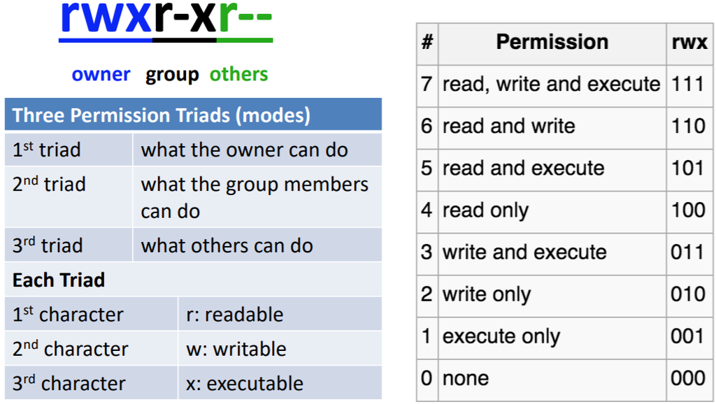

## 6.1 `chmod` Command

1. `chmod octal Myfile`
   - changes the permissions of file to octal, which can be found separately for user, group, and others
2. `chmod 777 Myfile`
   - changes `Myfile` permissions to read, write, execute for all
3. `chmod 755 Myfile`
   - rwx for owner, r-x for group and others

# 7 File Compression Related

1. `tar`
   - manipulates tape archives; creates and manipulates streaming archive files
2. `gzip`
   - conducts compression/decompression using Lempel-Ziv coding (LZ77)

## 7.1 `tar` Command

1. `tar -cf File.tar Files`
   - creates a tar named `File.tar` containing `Files`
2. `tar -xf File.tar`
   - extracts the files from `File.tar`
3. `tar -czf file.tar.gz files`
   - creates a tar with Gzip compression
4. `tar -xzf file.tar.gz`
   - extracts a tar using Gzip
5. `tar -cjf file.tar.bz2`
   - creates a tar with Bzip2 compression
6. `tar -xjf file.tar.bz2`
   - extracts a tar using Bzip2

## 7.2 `gzip` Command

1. `gzip Myfile`
   - compresses `Myfile` and renames it to `Myfile.gz`
2. `gzip -d Myfile.gz`
   - decompresses `Myfile.gz` back to `Myfile`

# 8 Other Useful Commands or Key Combinations

1. `clear`
   - clears the terminal screen
2. `exit`
   - logs out the current session
3. Ctrl-c
   - halts the current command
4. Ctrl-d
   - similar to **exit**
5. Ctrl-w
   - erase one word in the current line
6. Ctrl-u
   - erase the whole current line
7. `!!`
   - repeats the last command
8. `history`
   - lists command history
9. `!history#`
   - execute the #-th command in the command history